# ps-estimating-beta-opt-final

```python
import pandas as pd
import numpy as np
import matplotlib.pyplot as plt
import seaborn as sns
import os
import concurrent.futures
import math
from datetime import datetime
import warnings
warnings.filterwarnings('ignore')
import statsmodels.api as sm
```

## Beta of Every Firm for Every Year from 1995 to 2022 using previous 1 month, 3 month, 6 month, 12 month and 24 months data

## Note: Since it took a very long time to process the data due to its high dimensinoality i have saved all the beta computations to the disk and re-used them whenever necessary

## Note(2): I have also run multiple notebooks in parallel to compute all the data in concurrently so you may see multiple import statements as i have combined all the notebooks into one

```python
daily_data = pd.read_csv("dsf.csv", low_memory=False, parse_dates=True)
daily_data.head()
```

|  | PERMNO | date | SHRCD | PERMCO | HEXCD | HSICCD | CUSIP | PRC | VOL | RET | SHROUT | OPENPRC | vwretd |
| --- | --- | --- | --- | --- | --- | --- | --- | --- | --- | --- | --- | --- | --- |
| 0 | 10001 | 1993-01-04 | 11.0 | 7953 | 2 | 4925 | 36720410 | 14.50 | 150.0 | 0.035714 | 1080.0 | 14.50 | -0.002615 |
| 1 | 10001 | 1993-01-05 | 11.0 | 7953 | 2 | 4925 | 36720410 | -14.25 | 0.0 | -0.017241 | 1080.0 | NaN | -0.001476 |
| 2 | 10001 | 1993-01-06 | 11.0 | 7953 | 2 | 4925 | 36720410 | -14.25 | 0.0 | 0.000000 | 1080.0 | NaN | 0.001454 |
| 3 | 10001 | 1993-01-07 | 11.0 | 7953 | 2 | 4925 | 36720410 | 14.50 | 228.0 | 0.017544 | 1080.0 | 14.50 | -0.007372 |
| 4 | 10001 | 1993-01-08 | 11.0 | 7953 | 2 | 4925 | 36720410 | 14.50 | 1375.0 | 0.000000 | 1080.0 | 14.25 | -0.003886 |

```python
daily_data.isna().sum()
```

```
PERMNO           0
date             0
SHRCD         2432
PERMCO           0
HEXCD            0
HSICCD       29709
CUSIP            0
PRC         840999
VOL         840813
RET          46691
SHROUT       18684
OPENPRC    3570715
vwretd           0
dtype: int64
```

```python
daily_data['RET'].fillna(0, inplace=True)
```

```python
daily_data.isna().sum()
```

```
PERMNO           0
date             0
SHRCD         2432
PERMCO           0
HEXCD            0
HSICCD       29709
CUSIP            0
PRC         840999
VOL         840813
RET              0
SHROUT       18684
OPENPRC    3570715
vwretd           0
dtype: int64
```

```python
daily_data_copy = daily_data.copy(deep=True)
daily_data_copy['date'] = pd.to_datetime(daily_data['date'])
# daily_data_copy = daily_data
```

```python
daily_data_copy.dtypes
```

```
PERMNO              int64
date       datetime64[ns]
SHRCD             float64
PERMCO              int64
HEXCD               int64
HSICCD             object
CUSIP              object
PRC               float64
VOL               float64
RET                object
SHROUT            float64
OPENPRC           float64
vwretd            float64
dtype: object
```

```python
daily_data_copy['RET'] = pd.to_numeric(daily_data_copy['RET'], errors='coerce')
```

```python
daily_data_copy.columns
```

```
Index(['PERMNO', 'date', 'SHRCD', 'PERMCO', 'HEXCD', 'HSICCD', 'CUSIP', 'PRC',
       'VOL', 'RET', 'SHROUT', 'OPENPRC', 'vwretd'],
      dtype='object')
```

```python
# Convert the 'date' column to datetime format if it's not already
if daily_data_copy['date'].dtype == 'O':  # 'O' stands for object, typically strings
    daily_data_copy['date'] = pd.to_datetime(daily_data_copy['date'])

# Extract the year from the 'date' column and create a new 'year' column
daily_data_copy['year'] = daily_data_copy['date'].dt.year
```

```python
from collections import defaultdict


res = defaultdict(dict)

def helper(stock, year, period_months, period_name):
    # yearly_results = {
    #             'PERMNO': stock,
    #             'year': year
    #         }
    start_date = datetime(year - (2 if period_months == 24 else 1), 12, 31) - pd.DateOffset(months=period_months)
    end_date = datetime(year - 1, 12, 31)
    # print(f"Working on stock: {stock} | year: {year} | period_months: {period_months}")

    stock_data = daily_data_copy[daily_data_copy['PERMNO'] == stock].sort_values(by='date')
    window_data = stock_data[(stock_data['date'] > start_date) & (stock_data['date'] <= end_date)]

    if not window_data.empty:  # Check if there is any data in the computation window
        cov_matrix = window_data[['RET', 'vwretd']].astype(float).cov()
        cov_ret_vwretd = cov_matrix.loc['RET', 'vwretd']
        var_vwretd = window_data['vwretd'].astype(float).var()

        beta = cov_ret_vwretd / var_vwretd if var_vwretd > 0 else None  # Check if variance is greater than 0
        res[(stock, year)].update({period_name : beta})
    else:
        # yearly_results[period_name] = None  # Set beta as None if no data
        # res[(stock, year, period_name)] = None
        res[(stock, year)].update({period_name : None})
```

```python
periods = {'beta_1M': 1, 'beta_3M': 3, 'beta_6M': 6, 'beta_12M': 12, 'beta_24M': 24}
unique_permnos = daily_data_copy['PERMNO'].unique()

futs = []
with concurrent.futures.ThreadPoolExecutor(max_workers=64) as executor:
    for stock in unique_permnos:
        for year in range(1995, 2023):  # From 1995 to 2022
            for period_name, period_months in periods.items():
                futs.append(executor.submit(helper, stock, year, period_months, period_name))


futs_tuple = concurrent.futures.wait(futs)
assert not futs_tuple.not_done

beta_df = pd.DataFrame()


for key, val in res.items():
    stock, year = key
    row_dict = {
                'PERMNO': stock,
                'year': year
    }
    row_dict.update(val)
    beta_df = beta_df._append(row_dict, ignore_index=True)
```

## Interesting Note: The above piece of code was run on a 16-Core, 64GB Server on azure and took about 18 hours to run to completion, since i have used multithreading here are the stats for resource utilization at one point in timethe code execution

[figure not shown]

## And this was after it was done executing and holding the entire dataframe in memory just before writing to disk

[figure not shown]

```python
# Display the result
print(beta_df.head())
```

```
    PERMNO    year   beta_6M  beta_24M  beta_12M   beta_1M   beta_3M
0  10001.0  1996.0  0.579863  0.472431  0.754596 -0.845550  0.179443
1  10001.0  1999.0  0.231908  0.121115  0.253167  0.333916  0.004009
2  10001.0  1997.0 -0.595634  0.258602 -0.199948 -0.885812 -0.730757
3  10001.0  1998.0  0.064106  0.086084  0.071055  0.368796  0.060521
4  10001.0  1995.0  0.194006  0.365552  0.556163  0.023573  0.553003
```

```python
beta_df.to_csv("main_beta.csv")
```

```python
main_beta = pd.read_csv("main_beta.csv")
```

## Descriptive stats for Beta

```python
descriptive_stats_dict = {}

beta_columns = [col for col in main_beta.columns if 'beta' in col]

for col in beta_columns:
    # Compute descriptive statistics with specific percentiles
    descriptive_stats = main_beta[col].describe(
        percentiles=[.01, .05, .25, .5, .75, .95, .99]
    ).to_frame().rename(columns={col: 'value'})

    # Compute skewness and kurtosis
    descriptive_stats.loc['skewness'] = [main_beta[col].skew()]
    descriptive_stats.loc['kurtosis'] = [main_beta[col].kurtosis()]

    # Store the descriptive stats in the dictionary with the beta column as the key
    descriptive_stats_dict[col] = descriptive_stats

# Convert the descriptive stats dictionary to a DataFrame
descriptive_stats_df = pd.concat(descriptive_stats_dict, axis=1)

# Display the descriptive statistics DataFrame
print(descriptive_stats_df)
```

```
                beta_6M       beta_24M       beta_12M        beta_1M  \
                  value          value          value          value
count     218204.000000  259098.000000  226306.000000  211194.000000
mean           0.778362       0.748349       0.777697       0.754502
std            2.711810       1.628126       1.723098       1.772650
min        -1139.971111    -130.639261    -130.639261    -197.549285
1%            -1.344186      -1.016744      -1.139869      -3.259080
5%            -0.186974      -0.049292      -0.102252      -1.078368
25%            0.276337       0.305360       0.290938       0.102226
50%            0.754614       0.727966       0.749480       0.722354
75%            1.192466       1.114676       1.169551       1.320306
95%            2.063494       1.794334       1.961019       2.785519
99%            3.063409       2.584198       2.838640       4.782030
max          227.776124     600.599099     600.599099     227.776124
skewness    -337.792916     202.927501     196.179434       7.959886
kurtosis  143801.808425   73205.860326   66775.599580    2576.327499

                beta_3M
                  value
count     214066.000000
mean           0.778740
std            1.312732
min         -108.295322
1%            -1.793473
5%            -0.382131
25%            0.228766
50%            0.746172
75%            1.228693
95%            2.230954
99%            3.408553
max          227.776124
skewness      41.604053
kurtosis    6397.273744
```

## Beta Computation with Monthly Data

```python
import pandas as pd
import numpy as np
import matplotlib.pyplot as plt
import seaborn as sns
import os
import concurrent.futures
import math
from datetime import datetime
from scipy import stats
```

```python
msf_data = pd.read_csv("msf_1926_2022.csv", low_memory=False)
```

```python
for i in msf_data.columns:
    print(i, (msf_data[i] == 0).sum())
```

```
PERMNO 0
date 0
SHRCD 0
EXCHCD 62633
TICKER 0
COMNAM 0
PERMCO 0
ISSUNO 2271942
HEXCD 0
HSICCD 0
CUSIP 0
BIDLO 0
ASKHI 0
PRC 0
VOL 11609
RET 0
BID 0
ASK 0
SHROUT 2818
CFACPR 25117
CFACSHR 25117
ALTPRC 0
SPREAD 0
ALTPRCDT 0
RETX 0
vwretd 0
```

```python
# Define a list of categorical columns that need placeholder filling
categorical_cols = ['SHRCD', 'EXCHCD', 'TICKER', 'COMNAM', 'HSICCD']

# Convert 'SHRCD' and 'EXCHCD' to categorical and add 'Unknown' as a category, then fill missing values with 'Unknown'
for col in categorical_cols:
    msf_data[col] = msf_data[col].astype('category')
    msf_data[col] = msf_data[col].cat.add_categories(['Unknown'])
    msf_data[col].fillna('Unknown', inplace=True)

# Define a list of continuous columns that haven’t undergone linear interpolation
uninterpolated_cols = ['BIDLO', 'ASKHI', 'VOL', 'BID', 'ASK', 'SHROUT', 'CFACPR', 'CFACSHR']

# Interpolate or Forward-fill/Backward-fill for uninterpolated continuous variables
msf_data[uninterpolated_cols] = msf_data[uninterpolated_cols].interpolate(method='linear', limit_direction='both')

# Given the substantial amount of missing data in 'SPREAD', filling with the median value
msf_data['SPREAD'].fillna(msf_data['SPREAD'].median(), inplace=True)

# Convert the 'ALTPRCDT' to datetime, coerce errors to NaT
msf_data['ALTPRCDT'] = pd.to_datetime(msf_data['ALTPRCDT'], errors='coerce')

# Now find the minimum date ignoring NaT values
min_date = msf_data['ALTPRCDT'].min(skipna=True)

# Fill NaT values with the minimum date
msf_data['ALTPRCDT'].fillna(min_date, inplace=True)

# Define a list of columns that still have missing values after previous operations
remaining_na_cols = ['PRC', 'ALTPRC', 'vwretd']

# Interpolate or Forward-fill/Backward-fill for continuous variables with remaining missing values
msf_data[remaining_na_cols] = msf_data[remaining_na_cols].interpolate(method='linear', limit_direction='both')

# If interpolation does not fill all missing values, fill the remaining ones with median values of the respective columns
msf_data[remaining_na_cols] = msf_data[remaining_na_cols].apply(lambda x: x.fillna(x.median()))

# For 'RET' and 'RETX', consider filling with 0 as they are return columns and NaN might represent no return
msf_data[['RET', 'RETX']] = msf_data[['RET', 'RETX']].fillna(0)

# Check the DataFrame again for any remaining missing values and review if any further steps are needed.
print(msf_data.isna().sum())
```

```
PERMNO      0
date        0
SHRCD       0
EXCHCD      0
TICKER      0
COMNAM      0
PERMCO      0
ISSUNO      0
HEXCD       0
HSICCD      0
CUSIP       0
BIDLO       0
ASKHI       0
PRC         0
VOL         0
RET         0
BID         0
ASK         0
SHROUT      0
CFACPR      0
CFACSHR     0
ALTPRC      0
SPREAD      0
ALTPRCDT    0
RETX        0
vwretd      0
dtype: int64
```

```python
msf_data['date'] = pd.to_datetime(msf_data['date'])
```

```python
def to_numeric(value):
    try:
        return float(value)
    except ValueError:  # If conversion fails, return 0
        return 0.0

msf_data['RET'] = msf_data['RET'].map(to_numeric)
```

```python
msf_data['RET'].unique()
```

```
array([ 0.      , -0.257143,  0.365385, ...,  0.323765, -0.142168,
       -0.367334])
```

```python
msf_data['vwretd'].unique()
```

```
array([0.043061 , 0.00983  , 0.072501 , ..., 0.0119725, 0.002013 ,
       0.0015495])
```

```python
# Assuming msf_data['date'] is of datetime dtype, if not convert it
if msf_data['date'].dtype == 'object':
    msf_data['date'] = pd.to_datetime(msf_data['date'], errors='coerce')

# Define the date range
start_date = '1992-01-01'
end_date = '2022-12-31'

# Filter the DataFrame based on the date range and select the desired columns
filtered_msf_data = msf_data[(msf_data['date'] >= start_date) & (msf_data['date'] <= end_date)][['date', 'PERMNO','RET', 'vwretd']]

# Resetting index after filtering
filtered_msf_data.reset_index(drop=True, inplace=True)
```

```python
filtered_msf_data.head()
```

|  | date | PERMNO | RET | vwretd |
| --- | --- | --- | --- | --- |
| 0 | 1992-01-31 | 10001 | -0.051724 | -0.001164 |
| 1 | 1992-02-28 | 10001 | -0.200000 | 0.013355 |
| 2 | 1992-03-31 | 10001 | 0.081818 | -0.023699 |
| 3 | 1992-04-30 | 10001 | 0.010638 | 0.013414 |
| 4 | 1992-05-29 | 10001 | 0.010526 | 0.006407 |

```python
filtered_msf_data.shape
```

```
(2869200, 4)
```

```python
# Extract year from the 'date' column
filtered_msf_data['year'] = filtered_msf_data['date'].dt.year

# Define the periods in months for beta calculation
periods = {'beta_12M': 12, 'beta_24M': 24, 'beta_36M': 36}

# Initialize a list to store the results
results = []

# Loop over the unique PERMNOs (stocks) in the dataset
for stock in filtered_msf_data['PERMNO'].unique():
    stock_data = filtered_msf_data[filtered_msf_data['PERMNO'] == stock].sort_values(by='date')

    # Loop over the years for the stock from 1995 to 2022
    for year in range(1995, 2023):

        row = {'PERMNO': stock, 'year': year}

        # Loop over the different periods and calculate the beta values
        for period_name, period_length in periods.items():

            # Get data for the last 'period_length' months before the year
            end_date = pd.to_datetime(f"{year}-01-01")
            start_date = end_date - pd.DateOffset(months=period_length)
            window_data = stock_data[(stock_data['date'] < end_date) & (stock_data['date'] >= start_date)]

            if not window_data.empty and len(window_data.dropna(subset=['RET', 'vwretd'])) >= 2:
                cov_matrix = window_data[['RET', 'vwretd']].astype(float).cov()
                cov_ret_vwretd = cov_matrix.loc['RET', 'vwretd']
                var_vwretd = window_data['vwretd'].astype(float).var()

                # Calculate beta and append to the row dictionary
                beta = cov_ret_vwretd / var_vwretd if var_vwretd else None
                row[period_name] = beta

        # Append the row to the results list
        results.append(row)

# Create the resulting DataFrame
beta_msf_df = pd.DataFrame(results)

# Display the resulting DataFrame
print(beta_msf_df.head())
```

```
   PERMNO  year  beta_12M  beta_24M  beta_36M
0   10001  1995 -0.453394 -0.369001 -0.388514
1   10001  1996  1.230641  0.171053 -0.026688
2   10001  1997  0.354364  0.612644  0.227964
3   10001  1998  0.127096  0.229186  0.327610
4   10001  1999  0.099535  0.108624  0.149831
```

```python
# Create the resulting DataFrame
beta_msf_df = pd.DataFrame(results)

# Display the resulting DataFrame
print(beta_msf_df.head())
```

```
   PERMNO  year  beta_12M  beta_24M  beta_36M
0   10001  1995 -0.453394 -0.369001 -0.388514
1   10001  1996  1.230641  0.171053 -0.026688
2   10001  1997  0.354364  0.612644  0.227964
3   10001  1998  0.127096  0.229186  0.327610
4   10001  1999  0.099535  0.108624  0.149831
```

## Descriptive Stats for Montly Beta

```python
descriptive_stats_dict = {}

# Assuming beta_msf_df contains columns like beta_1M, beta_3M, beta_6M, beta_12M, beta_24M, beta_36M
beta_columns = [col for col in beta_msf_df.columns if 'beta' in col]

for col in beta_columns:
    # Compute descriptive statistics with specific percentiles
    descriptive_stats = beta_msf_df[col].describe(
        percentiles=[.01, .05, .25, .5, .75, .95, .99]
    ).to_frame().rename(columns={col: 'value'})

    # Compute skewness and kurtosis
    descriptive_stats.loc['skewness'] = [beta_msf_df[col].skew()]
    descriptive_stats.loc['kurtosis'] = [beta_msf_df[col].kurtosis()]

    # Store the descriptive stats in the dictionary with the beta column as the key
    descriptive_stats_dict[col] = descriptive_stats

# Convert the descriptive stats dictionary to a DataFrame
descriptive_stats_df = pd.concat(descriptive_stats_dict, axis=1)

# Display the descriptive statistics DataFrame
print(descriptive_stats_df)
```

```
               beta_12M       beta_24M       beta_36M
                  value          value          value
count     227817.000000  244085.000000  260526.000000
mean           0.979049       0.995521       0.980060
std            2.826552       2.566261       2.915614
min         -368.972704    -368.972704    -633.652455
1%            -3.635004      -2.600029      -2.544917
5%            -1.018145      -0.538566      -0.443648
25%            0.140986       0.274478       0.311738
50%            0.828152       0.872745       0.878776
75%            1.583882       1.513887       1.489417
95%            3.630522       3.170199       3.028418
99%            6.679471       5.463443       5.197740
max          481.449664     481.449664     481.449664
skewness      21.846052      27.176238     -30.662565
kurtosis    6166.885243    8468.157462   14258.021185
```

```python
beta_msf_df.to_csv("monthly_beta.csv")
```

## Beta Computation using the Welch(2021) Proposed Method

```python
import pandas as pd
import numpy as np
import matplotlib.pyplot as plt
import seaborn as sns
import os
import concurrent.futures
import math
from datetime import datetime
```

```python
daily_data = pd.read_csv("dsf.csv", low_memory=False)
```

```python
daily_data['RET'].fillna(0, inplace=True)
```

```python
daily_data_copy = daily_data.copy(deep=True)
daily_data_copy['date'] = pd.to_datetime(daily_data['date'])
```

```python
daily_data_copy['RET'] = pd.to_numeric(daily_data_copy['RET'], errors='coerce')
```

```python
# Convert the 'date' column to datetime format if it's not already
if daily_data_copy['date'].dtype == 'O':  # 'O' stands for object, typically strings
    daily_data_copy['date'] = pd.to_datetime(daily_data_copy['date'])

# Extract the year from the 'date' column and create a new 'year' column
daily_data_copy['year'] = daily_data_copy['date'].dt.year
```

```python
def winsorize_ret(row):
    lower_bound = -2 * row['vwretd']
    upper_bound = 4 * row['vwretd']

    # Winsorize the 'RET' value
    return min(max(row['RET'], lower_bound), upper_bound)
```

```python
daily_data_copy['winsorized_RET'] = daily_data_copy.apply(winsorize_ret, axis=1)
```

```python
# Now, for each stock and each year, calculate the Welch (2021) beta using the winsorized return series
results_welch = []

# Define a dictionary of periods (in days) for beta calculation
periods = {'beta_welch_1M': 21, 'beta_welch_3M': 63, 'beta_welch_6M': 126, 'beta_welch_12M': 252, 'beta_welch_24M': 504}

# Loop over the unique PERMNOs (stocks) in the dataset
for stock in daily_data_copy['PERMNO'].unique():
    stock_data = daily_data_copy[daily_data_copy['PERMNO'] == stock].sort_values(by='date')

    # Extract the unique years present in stock_data and filter for years between 1995 and 2022
    years = stock_data['date'].dt.year.unique()
    years = [year for year in years if 1995 <= year <= 2022]

    for year in years:
        # Initialize a dictionary to hold results for this stock-year
        result_dict = {'PERMNO': stock, 'year': year}

        # Define the start and end year for filtering data
        start_year = year - 2  # To cover up to 24 months
        end_year = year

        # Filter the stock_data for the given year range
        yearly_data = stock_data[(stock_data['date'].dt.year >= start_year) & (stock_data['date'].dt.year <= end_year)]

        # Loop over the different periods and calculate the beta values
        for period_name, period_length in periods.items():
            window_data = yearly_data.tail(period_length)  # Get the last 'period_length' rows

            if not window_data.empty and len(window_data.dropna(subset=['winsorized_RET', 'vwretd'])) >= 2:
                cov_matrix = window_data[['winsorized_RET', 'vwretd']].astype(float).cov()
                cov_ret_vwretd = cov_matrix.loc['winsorized_RET', 'vwretd']
                var_vwretd = window_data['vwretd'].astype(float).var()

                # Calculate beta and append to the result dictionary
                beta = cov_ret_vwretd / var_vwretd if var_vwretd else None
                result_dict[period_name] = beta

        # Append the result dictionary to the results list
        results_welch.append(result_dict)
```

```python
# Convert the results list to a DataFrame
beta_welch_df = pd.DataFrame(results_welch)

# Display the resulting DataFrame
print(beta_welch_df.head())
```

```
   PERMNO  year  beta_welch_1M  beta_welch_3M  beta_welch_6M  beta_welch_12M  \
0   10001  1995       2.192349       2.432148       2.347402        2.176088
1   10001  1996       1.718650       1.382727       1.975572        2.200020
2   10001  1997       2.134204       2.393592       2.251785        2.222657
3   10001  1998       1.920963       1.558192       2.259470        2.271952
4   10001  1999       0.925740       1.657755       1.801354        1.838198

   beta_welch_24M
0        2.355081
1        2.199539
2        2.210588
3        2.253805
4        2.083618
```

## Descriptive Stats for the welch beta computation

```python
# List of beta columns in beta_welch_df
beta_columns = ['beta_welch_1M', 'beta_welch_3M', 'beta_welch_6M', 'beta_welch_12M', 'beta_welch_24M']

# Initialize a dictionary to hold the descriptive statistics
descriptive_stats_dict = {}

# Iterate over each beta column and calculate the descriptive statistics
for col in beta_columns:
    series = beta_welch_df[col].dropna()  # Drop NA values before computing statistics

    # Compute descriptive statistics
    descriptive_stats = series.describe(percentiles=[.01, .05, .25, .5, .75, .95, .99]).to_frame().rename(columns={col: f"{col}"})

    # Compute skewness and kurtosis
    descriptive_stats.loc['skewness'] = [series.skew()]
    descriptive_stats.loc['kurtosis'] = [series.kurtosis()]
    descriptive_stats.loc['N'] = [len(series)]

    # Store the descriptive stats in the dictionary
    descriptive_stats_dict[col] = descriptive_stats

# Convert the descriptive stats dictionary to a DataFrame
descriptive_stats_df = pd.concat(descriptive_stats_dict, axis=1)

# Display the descriptive statistics DataFrame
print(descriptive_stats_df)
```

```
          beta_welch_1M  beta_welch_3M  beta_welch_6M beta_welch_12M  \
          beta_welch_1M  beta_welch_3M  beta_welch_6M beta_welch_12M
count     227641.000000  227726.000000  227818.000000  228056.000000
mean           2.160018       2.210743       2.336460       2.378539
std            0.598728       0.417687       0.345825       0.323962
min           -2.081013      -2.081013      -2.081013      -2.081013
1%             0.529249       1.209361       1.484684       1.559835
5%             1.151820       1.545779       1.799205       1.900620
25%            1.796562       1.931891       2.126413       2.174230
50%            2.190005       2.228925       2.342945       2.384296
75%            2.555072       2.488939       2.560463       2.587069
95%            3.094575       2.857864       2.862645       2.860089
99%            3.491434       3.162732       3.114649       3.094169
max            7.878363       7.878363       8.021911      11.948486
skewness      -0.357812      -0.186921      -0.400754      -0.222467
kurtosis       0.924069       1.907074       5.094485      11.077553
N         227641.000000  227726.000000  227818.000000  228056.000000

         beta_welch_24M
         beta_welch_24M
count     228424.000000
mean           2.401564
std            0.310963
min           -2.081013
1%             1.544639
5%             1.982600
25%            2.213654
50%            2.402072
75%            2.594981
95%            2.842871
99%            3.064168
max           11.571816
skewness       0.333704
kurtosis      25.440006
N         228424.000000
```

```python
beta_welch_df.to_csv('beta_welch_df.csv')
```

```python
daily_data.columns
```

```
Index(['PERMNO', 'date', 'SHRCD', 'PERMCO', 'HEXCD', 'HSICCD', 'CUSIP', 'PRC',
       'VOL', 'RET', 'SHROUT', 'OPENPRC', 'vwretd'],
      dtype='object')
```

```python
monthly_beta_sdf = pd.read_csv("monthly_beta.csv")
```

```python
monthly_beta_sdf.head()
```

|  | Unnamed: 0 | PERMNO | year | beta_12M | beta_24M | beta_36M |
| --- | --- | --- | --- | --- | --- | --- |
| 0 | 0 | 10001 | 1995 | -0.453394 | -0.369001 | -0.388514 |
| 1 | 1 | 10001 | 1996 | 1.230641 | 0.171053 | -0.026688 |
| 2 | 2 | 10001 | 1997 | 0.354364 | 0.612644 | 0.227964 |
| 3 | 3 | 10001 | 1998 | 0.127096 | 0.229186 | 0.327610 |
| 4 | 4 | 10001 | 1999 | 0.099535 | 0.108624 | 0.149831 |

## Correlation Across Beta Measures

```python
main_beta_df = pd.read_csv("main_beta.csv")
main_beta_df.dtypes
```

```
Unnamed: 0      int64
PERMNO        float64
year          float64
beta_6M       float64
beta_24M      float64
beta_12M      float64
beta_1M       float64
beta_3M       float64
dtype: object
```

```python
main_beta_df['PERMNO'] = main_beta_df['PERMNO'].astype(int)
main_beta_df['year'] = main_beta_df['year'].astype(int)
```

```python
main_beta_df.head()
```

|  | Unnamed: 0 | PERMNO | year | beta_6M | beta_24M | beta_12M | beta_1M | beta_3M |
| --- | --- | --- | --- | --- | --- | --- | --- | --- |
| 0 | 0 | 10001 | 1996 | 0.579863 | 0.472431 | 0.754596 | -0.845550 | 0.179443 |
| 1 | 1 | 10001 | 1999 | 0.231908 | 0.121115 | 0.253167 | 0.333916 | 0.004009 |
| 2 | 2 | 10001 | 1997 | -0.595634 | 0.258602 | -0.199948 | -0.885812 | -0.730757 |
| 3 | 3 | 10001 | 1998 | 0.064106 | 0.086084 | 0.071055 | 0.368796 | 0.060521 |
| 4 | 4 | 10001 | 1995 | 0.194006 | 0.365552 | 0.556163 | 0.023573 | 0.553003 |

```python
monthly_beta = pd.read_csv("monthly_beta.csv")
```

```python
monthly_beta.head()
```

|  | Unnamed: 0 | PERMNO | year | beta_12M | beta_24M | beta_36M |
| --- | --- | --- | --- | --- | --- | --- |
| 0 | 0 | 10001 | 1995 | -0.453394 | -0.369001 | -0.388514 |
| 1 | 1 | 10001 | 1996 | 1.230641 | 0.171053 | -0.026688 |
| 2 | 2 | 10001 | 1997 | 0.354364 | 0.612644 | 0.227964 |
| 3 | 3 | 10001 | 1998 | 0.127096 | 0.229186 | 0.327610 |
| 4 | 4 | 10001 | 1999 | 0.099535 | 0.108624 | 0.149831 |

```python
welch_beta = pd.read_csv("beta_welch_df.csv")
```

```python
welch_beta.head()
```

|  | Unnamed: 0 | PERMNO | year | beta_welch_1M | beta_welch_3M | beta_welch_6M | beta_welch_12M | beta_welch_24M |
| --- | --- | --- | --- | --- | --- | --- | --- | --- |
| 0 | 0 | 10001 | 1995 | 2.192349 | 2.432148 | 2.347402 | 2.176088 | 2.355081 |
| 1 | 1 | 10001 | 1996 | 1.718650 | 1.382727 | 1.975572 | 2.200020 | 2.199539 |
| 2 | 2 | 10001 | 1997 | 2.134204 | 2.393592 | 2.251785 | 2.222657 | 2.210588 |
| 3 | 3 | 10001 | 1998 | 1.920963 | 1.558192 | 2.259470 | 2.271952 | 2.253805 |
| 4 | 4 | 10001 | 1999 | 0.925740 | 1.657755 | 1.801354 | 1.838198 | 2.083618 |

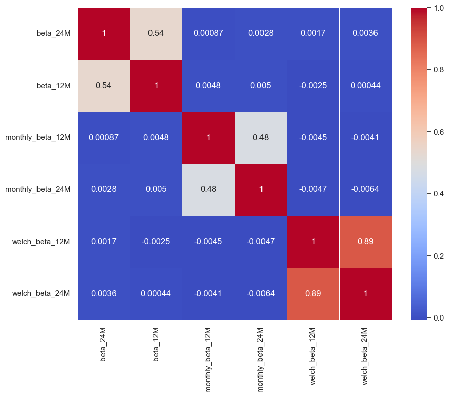

```python
#Merge the dataframes on common columns
merged_df = main_beta_df[['beta_24M', 'beta_12M']].copy()
merged_df['monthly_beta_12M'] = monthly_beta['beta_12M']
merged_df['monthly_beta_24M'] = monthly_beta['beta_24M']
merged_df['welch_beta_12M'] = welch_beta['beta_welch_12M']
merged_df['welch_beta_24M'] = welch_beta['beta_welch_24M']

# Compute the correlation matrix
corr_matrix = merged_df.corr()

# Set a nice Seaborn theme and plot the heatmap
sns.set_theme(style="white")
plt.figure(figsize=(10, 8))
sns.heatmap(corr_matrix, annot=True, cmap="coolwarm", linewidths=.5)
plt.show()
```

## Correaltion of the main beta measure and the welch measure

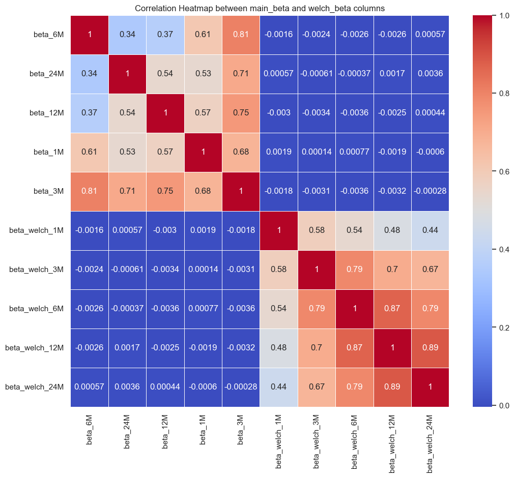

```python
# Exclude specified columns
cols_to_exclude = ['PERMNO', 'year', 'Unnamed: 0']
main_beta_reduced = main_beta_df.drop(columns=cols_to_exclude, errors='ignore')
welch_beta_reduced = welch_beta.drop(columns=cols_to_exclude, errors='ignore')

# Combine the dataframes
combined_df = main_beta_reduced.join(welch_beta_reduced, rsuffix='_welch')

# Compute the correlation matrix
corr_matrix = combined_df.corr()

# Set a Seaborn theme and plot the heatmap
sns.set_theme(style="white")
plt.figure(figsize=(12, 10))
sns.heatmap(corr_matrix, annot=True, cmap="coolwarm", linewidths=.5)
plt.title("Correlation Heatmap between main_beta and welch_beta columns")
plt.show()
```

## Computing Mean Beta Across the Industries and plotting the values

```python
# Bin edges and industry labels
bin_edges = [0, 999, 1499, 1799, 3999, 4999, 5199, 5999, 6799, 8999, 9999]
industry_labels = [
    'Agriculture, Forestry and Fishing',
    'Mining',
    'Construction',
    'Manufacturing',
    'Transportation and other Utilities',
    'Wholesale Trade',
    'Retail Trade',
    'Finance, Insurance and Real Estate',
    'Services',
    'Public Administration'
]

# Extracting the necessary columns from daily_data_copy
ids_industry_df = daily_data_copy[['PERMNO', 'HSICCD']].drop_duplicates()

# Convert 'HSICCD' to numeric, errors='coerce' will replace non-numeric values with NaN
ids_industry_df['HSICCD'] = pd.to_numeric(ids_industry_df['HSICCD'], errors='coerce')

# Apply the pd.cut operation
ids_industry_df['industry'] = pd.cut(ids_industry_df['HSICCD'], bins=bin_edges, labels=industry_labels, right=True)

# Add industry column to monthly_beta_df and beta_welch_df
monthly_beta_sdf = pd.merge(monthly_beta_sdf, ids_industry_df, on='PERMNO', how='left')
beta_welch_df = pd.merge(beta_welch_df, ids_industry_df, on='PERMNO', how='left')
```

```python
# Define a function to plot the beta values for each industry over the years
def plot_beta_values(df, beta_columns, title_prefix):
    for beta_col in beta_columns:
        plt.figure(figsize=(10,6))
        industry_beta_df = df.groupby(['industry', 'year'])[beta_col].mean().unstack(level=0)
        industry_beta_df.plot(ax=plt.gca())
        plt.title(f"{title_prefix} - {beta_col}")
        plt.ylabel('Beta')
        plt.xlabel('Year')
        plt.legend(loc='center left', bbox_to_anchor=(1.0, 0.5))
        plt.show()

# Define the beta columns for each dataframe
monthly_beta_columns = ['beta_12M', 'beta_24M', 'beta_36M']
welch_beta_columns = ['beta_welch_1M', 'beta_welch_3M', 'beta_welch_6M', 'beta_welch_12M', 'beta_welch_24M']
```

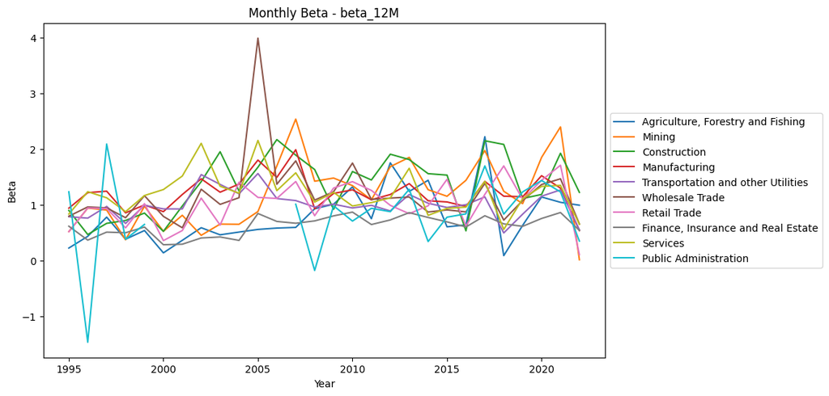

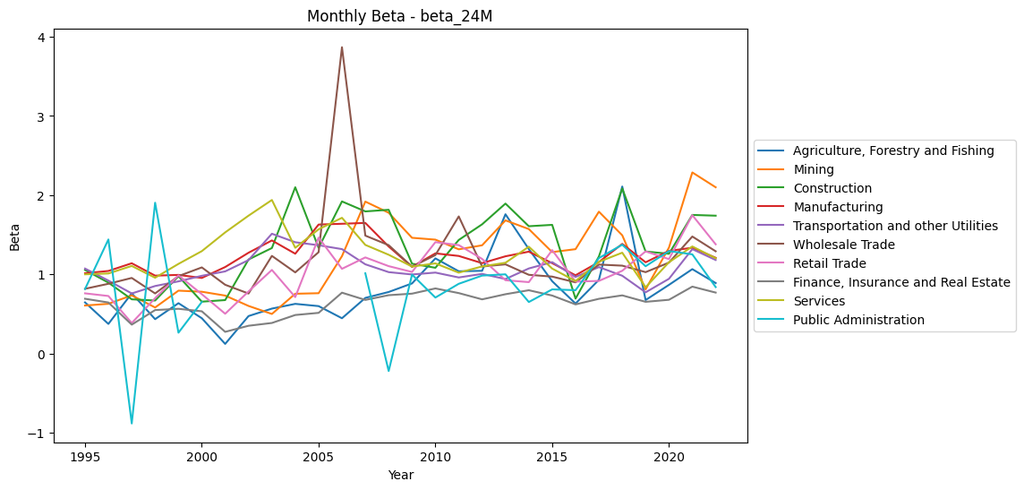

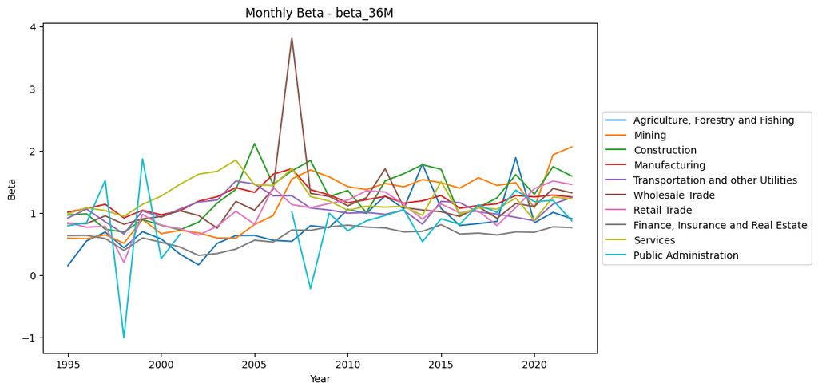

```python
# Plot the beta values
plot_beta_values(monthly_beta_sdf, monthly_beta_columns, "Monthly Beta")
```

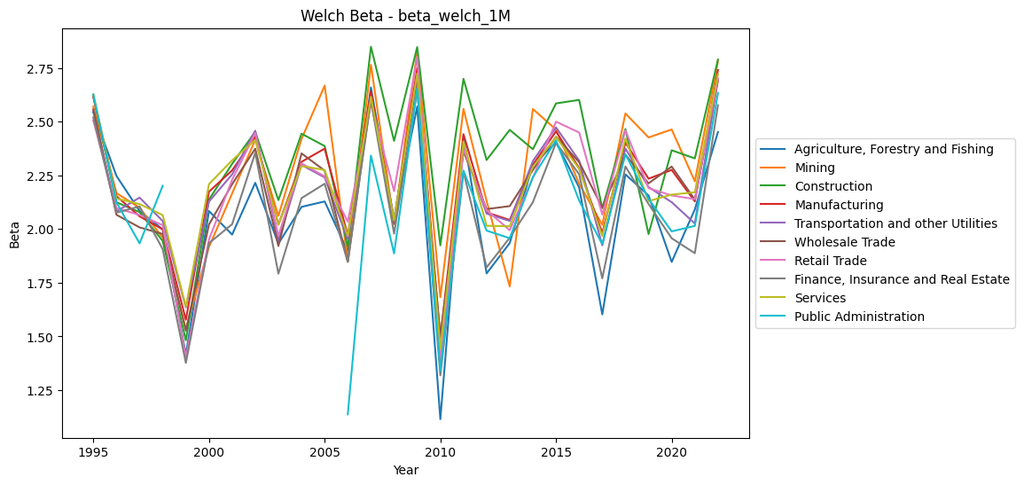

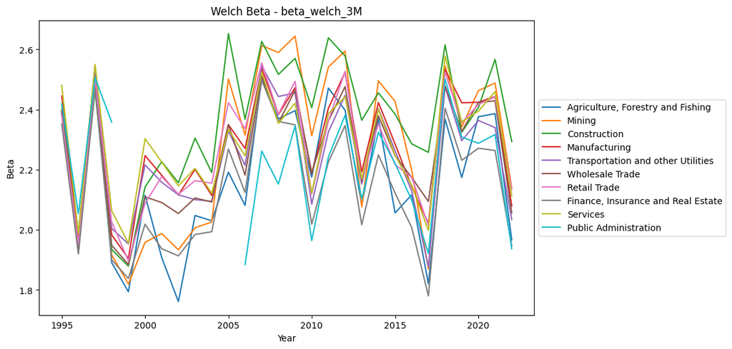

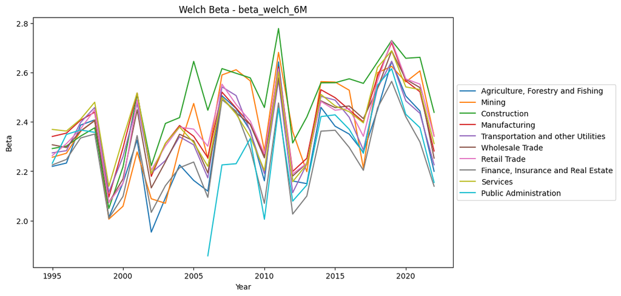

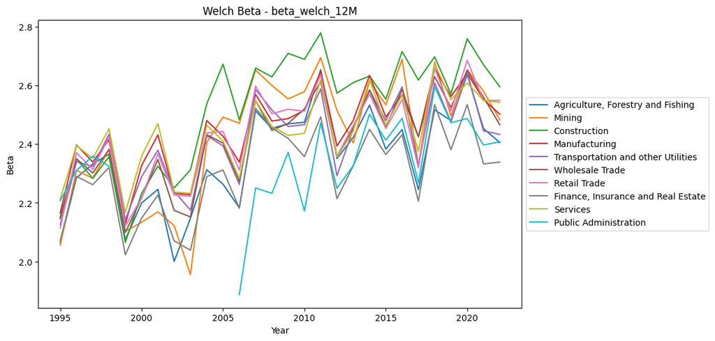

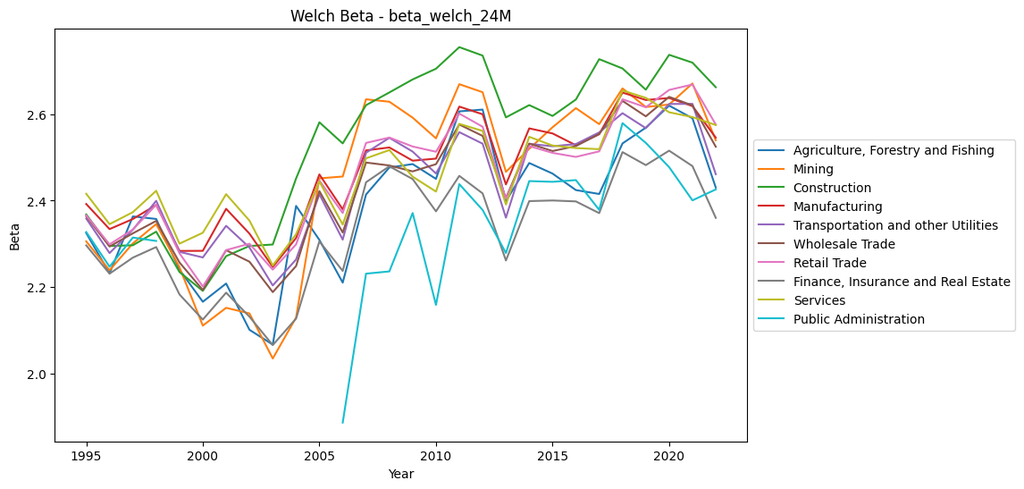

```python
plot_beta_values(beta_welch_df, welch_beta_columns, "Welch Beta")
```

```python
main_beta_df = pd.read_csv("main_beta.csv")
main_beta_df['PERMNO'] = main_beta_df['PERMNO'].astype(int)
main_beta_df['year'] = main_beta_df['year'].astype(int)
```

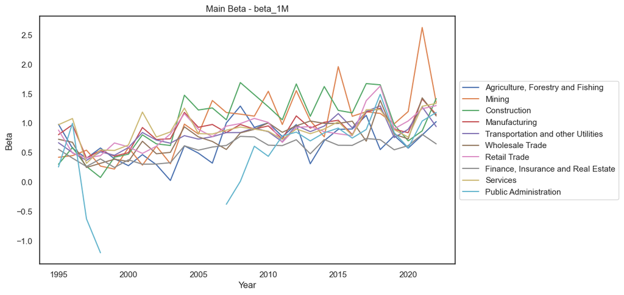

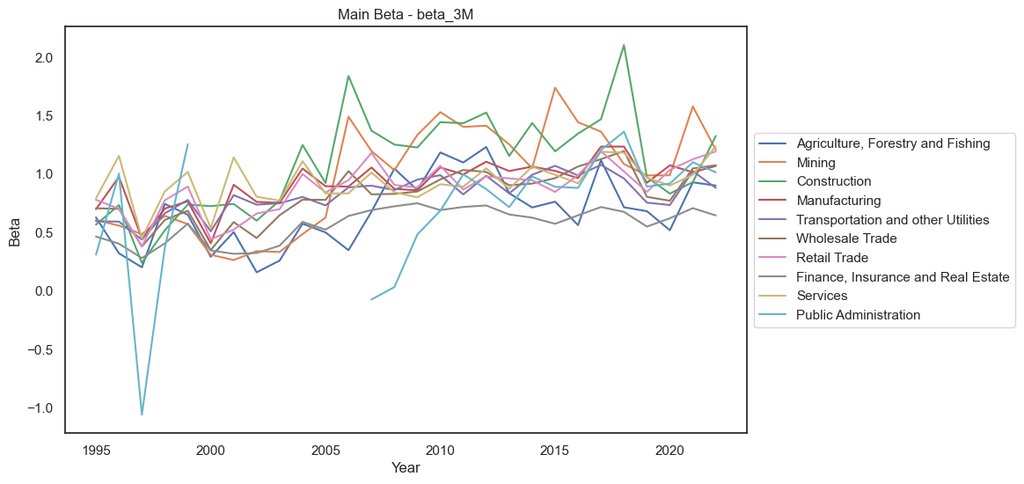

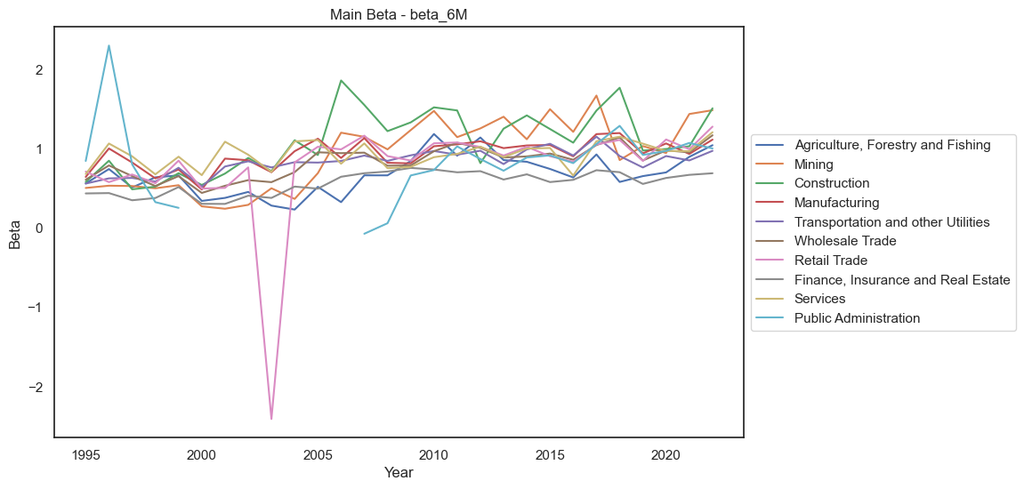

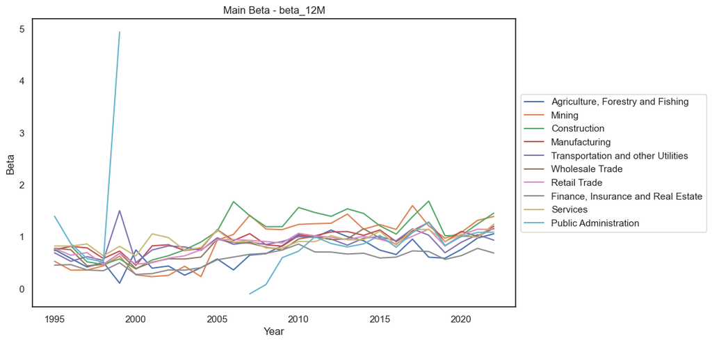

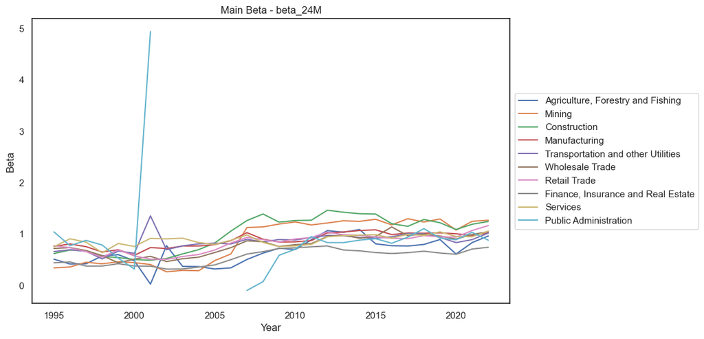

```python
# Bin edges and industry labels
bin_edges = [0, 999, 1499, 1799, 3999, 4999, 5199, 5999, 6799, 8999, 9999]
industry_labels = [
    'Agriculture, Forestry and Fishing',
    'Mining',
    'Construction',
    'Manufacturing',
    'Transportation and other Utilities',
    'Wholesale Trade',
    'Retail Trade',
    'Finance, Insurance and Real Estate',
    'Services',
    'Public Administration'
]

# Extracting the necessary columns from daily_data
ids_industry_df = daily_data[['PERMNO', 'HSICCD']].drop_duplicates()

# Convert 'HSICCD' to numeric, errors='coerce' will replace non-numeric values with NaN
ids_industry_df['HSICCD'] = pd.to_numeric(ids_industry_df['HSICCD'], errors='coerce')

# Apply the pd.cut operation
ids_industry_df['industry'] = pd.cut(ids_industry_df['HSICCD'], bins=bin_edges, labels=industry_labels, right=True)

# Add industry column to main_beta_df
main_beta_df = pd.merge(main_beta_df, ids_industry_df, on='PERMNO', how='left')

# Define a function to plot the beta values for each industry over the years
def plot_beta_values(df, beta_columns, title_prefix):
    for beta_col in beta_columns:
        plt.figure(figsize=(10,6))
        industry_beta_df = df.groupby(['industry', 'year'])[beta_col].mean().unstack(level=0)
        industry_beta_df.plot(ax=plt.gca())
        plt.title(f"{title_prefix} - {beta_col}")
        plt.ylabel('Beta')
        plt.xlabel('Year')
        plt.legend(loc='center left', bbox_to_anchor=(1.0, 0.5))
        plt.show()

# Define the beta columns for main_beta_df
main_beta_columns = ['beta_1M', 'beta_3M','beta_6M','beta_12M','beta_24M']

# Plot the beta values
plot_beta_values(main_beta_df, main_beta_columns, "Main Beta")
```

## Main Beta (computed using all daily data)

- Detail-Oriented: Captures the most detailed representation of a stock's relationship with the market due to its utilization of daily data.
- Industry Recognition: Commonly employed in many financial analyses, making it widely recognized and understood in the industry.

## Monthly Beta (computed using monthly data)

- Long-term Perspective: Provides a clearer long-term picture by averaging returns over a month, potentially filtering out short-term noise.
- Stability: Offers stability, being less influenced by daily market disturbances or transient events.

## Welch Beta (computed using the Welch (2021) method)

- Robustness: The Welch Beta methodology introduces a robust estimation that considers outliers in daily stock rates of return. By winsorizing extreme returns, it aims to provide a more accurate beta estimation.
- Superior Predictive Capabilities: The paper claims that the "slope-winsorized" beta estimator predicts future betas more effectively than other popular methods, including OLS betas and Bloomberg betas.
- Efficiency: The method is designed to be easy to implement, needing only a single-pass formula, making it efficient for practical applications.

Given the insights from the Welch (2021) paper and the unique characteristics of each beta, the choice would depend on the specific use case and audience. For instance, while the Welch Beta offers robustness and better predictive capabilities, the Monthly Beta might be preferred for its clear long-term perspective.

### Beta Computation

Beta, in the context of stocks and finance, measures the volatility or risk of a particular stock relative to the overall market. In other words:

- A beta of 1 indicates that the stock's price moves in tandem with the market.
- A beta greater than 1 indicates that the stock's price is more volatile than the market.
- A beta less than 1 indicates that the stock's price is less volatile than the market.

### Justifications for Choosing Specific Betas

#### Main Beta (Daily Data Beta):

- Comprehensive View: Calculated using all available daily data, this beta provides a more granular and comprehensive view of stock volatility.
- Reflects Short-Term Movements: With daily data, this beta can capture short-term market movements and fluctuations, making it suitable for short-term trading strategies or analysis.
- Wider Data Spectrum: Leveraging all available data points can potentially lead to a more robust beta estimation.

#### Monthly Beta:

- Reduced Noise: Monthly aggregation can filter out daily noise and provide a clearer picture of longer-term trends.
- Suitability for Longer-Term Analysis: For investors or analysts looking at medium to long-term strategies, monthly beta provides a balance between granularity and trend clarity.
- Efficiency: Aggregating data monthly can make computations more manageable and efficient, especially with large datasets.

#### Welch Beta:

- Robustness: As proposed in Welch (2021), this method offers a robust beta estimation by winsorizing extreme returns, making it less sensitive to outliers.
- Improved Predictive Power: The Welch method has been shown to predict future betas better than some other traditional methods, as stated in the paper.
- Single-Pass Computation: The methodology is straightforward and doesn't require iterative processes or complex computations.

# Forming deciles of the betas and using equal weighted portfolio

### First, we'll choose the Welch beta for 12 months (`beta_welch_12M`) as our specific beta for this analysis, primarily due to the following reasons:

1. Duration: A 12-month period offers a balance between capturing the short-term market dynamics and providing a long enough window to observe persistent patterns.
2. Welch's Robustness: As discussed earlier, the Welch method introduces a robustness to the beta computation by winsorizing extreme values. This can help in filtering out potential outliers, leading to a more reliable beta estimation.

```python
# Form deciles for each year, as beta values can shift from year to year
welch_beta['decile'] = welch_beta.groupby('year')['beta_welch_12M'].transform(
    lambda x: pd.qcut(x, 10, labels=False, duplicates='drop')
) + 1

# Display the head of the welch_beta dataframe to verify
print(welch_beta.head())
```

```
   Unnamed: 0  PERMNO  year  beta_welch_1M  beta_welch_3M  beta_welch_6M  \
0           0   10001  1995       2.192349       2.432148       2.347402
1           1   10001  1996       1.718650       1.382727       1.975572
2           2   10001  1997       2.134204       2.393592       2.251785
3           3   10001  1998       1.920963       1.558192       2.259470
4           4   10001  1999       0.925740       1.657755       1.801354

   beta_welch_12M  beta_welch_24M  decile
0        2.176088        2.355081     7.0
1        2.200020        2.199539     2.0
2        2.222657        2.210588     4.0
3        2.271952        2.253805     3.0
4        1.838198        2.083618     1.0
```

```python
msf_data = pd.read_csv("msf_1926_2022.csv", low_memory=False)
# Define a list of categorical columns that need placeholder filling
categorical_cols = ['SHRCD', 'EXCHCD', 'TICKER', 'COMNAM', 'HSICCD']

# Convert 'SHRCD' and 'EXCHCD' to categorical and add 'Unknown' as a category, then fill missing values with 'Unknown'
for col in categorical_cols:
    msf_data[col] = msf_data[col].astype('category')
    msf_data[col] = msf_data[col].cat.add_categories(['Unknown'])
    msf_data[col].fillna('Unknown', inplace=True)

# Define a list of continuous columns that haven’t undergone linear interpolation
uninterpolated_cols = ['BIDLO', 'ASKHI', 'VOL', 'BID', 'ASK', 'SHROUT', 'CFACPR', 'CFACSHR']

# Interpolate or Forward-fill/Backward-fill for uninterpolated continuous variables
msf_data[uninterpolated_cols] = msf_data[uninterpolated_cols].interpolate(method='linear', limit_direction='both')

# Given the substantial amount of missing data in 'SPREAD', filling with the median value
msf_data['SPREAD'].fillna(msf_data['SPREAD'].median(), inplace=True)

# Convert the 'ALTPRCDT' to datetime, coerce errors to NaT
msf_data['ALTPRCDT'] = pd.to_datetime(msf_data['ALTPRCDT'], errors='coerce')

# Now find the minimum date ignoring NaT values
min_date = msf_data['ALTPRCDT'].min(skipna=True)

# Fill NaT values with the minimum date
msf_data['ALTPRCDT'].fillna(min_date, inplace=True)

# Define a list of columns that still have missing values after previous operations
remaining_na_cols = ['PRC', 'ALTPRC', 'vwretd']

# Interpolate or Forward-fill/Backward-fill for continuous variables with remaining missing values
msf_data[remaining_na_cols] = msf_data[remaining_na_cols].interpolate(method='linear', limit_direction='both')

# If interpolation does not fill all missing values, fill the remaining ones with median values of the respective columns
msf_data[remaining_na_cols] = msf_data[remaining_na_cols].apply(lambda x: x.fillna(x.median()))

# For 'RET' and 'RETX', consider filling with 0 as they are return columns and NaN might represent no return
msf_data[['RET', 'RETX']] = msf_data[['RET', 'RETX']].fillna(0)

msf_data['date'] = pd.to_datetime(msf_data['date'])
# Assuming msf_data['date'] is of datetime dtype, if not convert it
if msf_data['date'].dtype == 'object':
    msf_data['date'] = pd.to_datetime(msf_data['date'], errors='coerce')

# Define the date range
start_date = '1995-01-01'
end_date = '2022-12-31'

# Filter the DataFrame based on the date range and select the desired columns
filtered_msf_data = msf_data[(msf_data['date'] >= start_date) & (msf_data['date'] <= end_date)][['date', 'PERMNO','RET', 'vwretd']]

# Resetting index after filtering
filtered_msf_data.reset_index(drop=True, inplace=True)
# Extract year from the 'date' column
filtered_msf_data['year'] = filtered_msf_data['date'].dt.year
```

```python
filtered_msf_data.head()
```

|  | date | PERMNO | RET | vwretd | year |
| --- | --- | --- | --- | --- | --- |
| 0 | 1995-01-31 | 10001 | -0.031250 | 0.020353 | 1995 |
| 1 | 1995-02-28 | 10001 | -0.026210 | 0.039647 | 1995 |
| 2 | 1995-03-31 | 10001 | 0.006377 | 0.027064 | 1995 |
| 3 | 1995-04-28 | 10001 | 0.000000 | 0.025048 | 1995 |
| 4 | 1995-05-31 | 10001 | 0.050000 | 0.033909 | 1995 |

```python
# Assuming you've already defined welch_beta and filtered_msf_data

# Merge the two DataFrames
merged_data = pd.merge(filtered_msf_data, welch_beta, on=['year', 'PERMNO'])

# Convert the RET and vwretd columns to float
merged_data['RET'] = pd.to_numeric(merged_data['RET'], errors='coerce')
merged_data['vwretd'] = pd.to_numeric(merged_data['vwretd'], errors='coerce')

# Calculate the excess return
merged_data['excess_return'] = merged_data['RET'] - merged_data['vwretd']

# Group by decile and year and calculate average beta and equal-weighted excess return
portfolio_summary = merged_data.groupby(['decile', 'year']).agg(
    avg_beta=('beta_welch_12M', 'mean'),
    avg_excess_return=('excess_return', 'mean')
).reset_index()

# Calculate the difference between portfolio 10 and portfolio 1 for each year
difference_df = portfolio_summary.pivot(index='year', columns='decile', values=['avg_beta', 'avg_excess_return'])

if 10 in difference_df['avg_beta'].columns and 1 in difference_df['avg_beta'].columns:
    difference_df['beta_diff'] = difference_df['avg_beta'][10] - difference_df['avg_beta'][1]
    difference_df['return_diff'] = difference_df['avg_excess_return'][10] - difference_df['avg_excess_return'][1]
    result = difference_df[['beta_diff', 'return_diff']]
else:
    result = "Decile 10 or Decile 1 data is missing."

print(result)
```

```
       beta_diff return_diff
decile
year
1995    0.859115    0.054288
1996    0.744599    0.050680
1997    0.712649    0.047129
1998    0.766091    0.055556
1999    0.807829    0.110720
2000    0.947753    0.030642
2001    1.046603    0.007584
2002    0.910525   -0.020600
2003    0.992259    0.050624
2004    0.953199    0.012559
2005    0.893934    0.029175
2006    1.102746    0.027680
```

[output cut: 16 more lines]

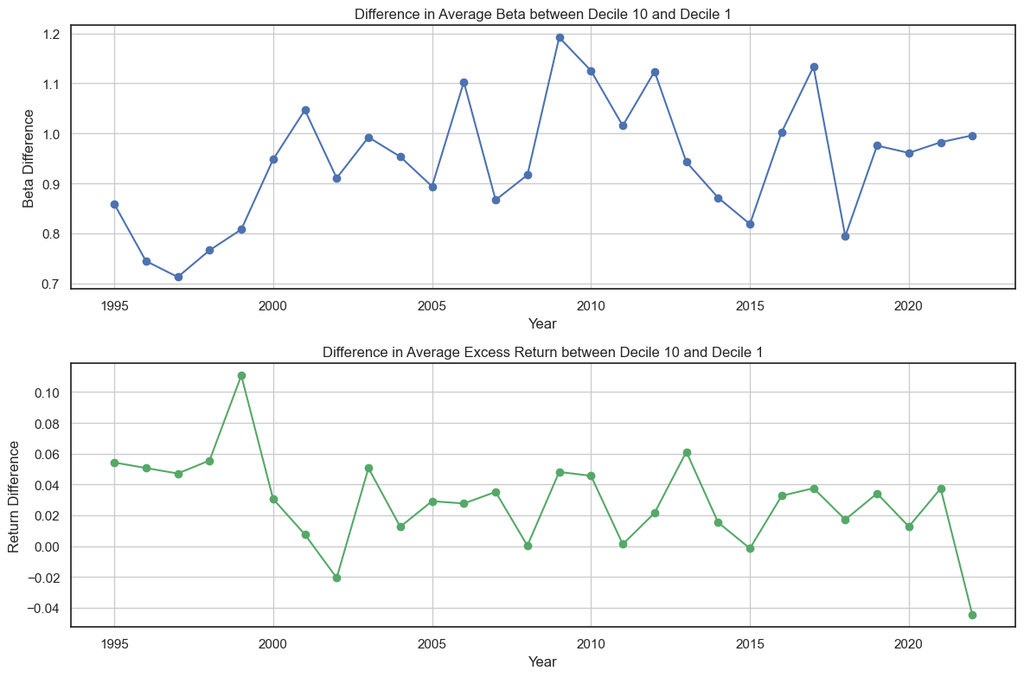

```python
#Check if the result contains the necessary columns for plotting
if isinstance(result, pd.DataFrame) and 'beta_diff' in result.columns and 'return_diff' in result.columns:

    fig, axes = plt.subplots(nrows=2, ncols=1, figsize=(12, 8))

    # Plotting difference in beta
    result['beta_diff'].plot(ax=axes[0], marker='o')
    axes[0].set_title('Difference in Average Beta between Decile 10 and Decile 1')
    axes[0].set_ylabel('Beta Difference')
    axes[0].set_xlabel('Year')
    axes[0].grid(True)

    # Plotting difference in excess returns
    result['return_diff'].plot(ax=axes[1], marker='o', color='g')
    axes[1].set_title('Difference in Average Excess Return between Decile 10 and Decile 1')
    axes[1].set_ylabel('Return Difference')
    axes[1].set_xlabel('Year')
    axes[1].grid(True)

    plt.tight_layout()
    plt.show()
```

## Newey-West t-statistic

```python
import statsmodels.api as sm
portfolio_excess_returns = result['return_diff']

# Regress the portfolio excess returns on a constant to obtain an intercept
X = sm.add_constant(np.ones_like(portfolio_excess_returns))
model = sm.OLS(portfolio_excess_returns, X).fit()

# Compute the Newey-West adjusted standard errors
nw_cov = sm.stats.sandwich_covariance.cov_hac(model, nlags=5)
nw_se = np.sqrt(nw_cov[0, 0])  # Extract the standard error for the constant

# Average of the portfolio excess returns
avg_excess_return = portfolio_excess_returns.mean()

# Compute the Newey-West t-statistic
t_stat_nw = avg_excess_return / nw_se

print("Newey-West t-statistic:", t_stat_nw)
```

```
Newey-West t-statistic: 4.957384786527973
```

## Value Weighted portfolio with beta Deciles

```python
welch_df = pd.read_csv("beta_welch_df.csv")
```

```python
welch_df.columns
```

```
Index(['Unnamed: 0', 'PERMNO', 'year', 'beta_welch_1M', 'beta_welch_3M',
       'beta_welch_6M', 'beta_welch_12M', 'beta_welch_24M'],
      dtype='object')
```

```python
monthly_df = pd.read_csv("msf_1926_2022.csv")
```

```python
# Assuming the dataframe is named monthly_df, based on the information provided
# Replace msf_data with monthly_df in the provided block of code

categorical_cols = ['SHRCD', 'EXCHCD', 'TICKER', 'COMNAM', 'HSICCD']

# Convert 'SHRCD' and 'EXCHCD' to categorical and add 'Unknown' as a category, then fill missing values with 'Unknown'
for col in categorical_cols:
    monthly_df[col] = monthly_df[col].astype('category')
    monthly_df[col] = monthly_df[col].cat.add_categories(['Unknown'])
    monthly_df[col].fillna('Unknown', inplace=True)

# Define a list of continuous columns that haven’t undergone linear interpolation
uninterpolated_cols = ['BIDLO', 'ASKHI', 'VOL', 'BID', 'ASK', 'SHROUT', 'CFACPR', 'CFACSHR']

# Interpolate or Forward-fill/Backward-fill for uninterpolated continuous variables
monthly_df[uninterpolated_cols] = monthly_df[uninterpolated_cols].interpolate(method='linear', limit_direction='both')

# Given the substantial amount of missing data in 'SPREAD', filling with the median value
monthly_df['SPREAD'].fillna(monthly_df['SPREAD'].median(), inplace=True)

# Convert the 'ALTPRCDT' and 'date' to datetime, coerce errors to NaT
monthly_df['ALTPRCDT'] = pd.to_datetime(monthly_df['ALTPRCDT'], errors='coerce')
monthly_df['date'] = pd.to_datetime(monthly_df['date'], errors='coerce')

# Now find the minimum date ignoring NaT values
min_date = monthly_df['ALTPRCDT'].min(skipna=True)

# Fill NaT values with the minimum date
monthly_df['ALTPRCDT'].fillna(min_date, inplace=True)

# Define a list of columns that still have missing values after previous operations
remaining_na_cols = ['PRC', 'ALTPRC', 'vwretd']

# Interpolate or Forward-fill/Backward-fill for continuous variables with remaining missing values
monthly_df[remaining_na_cols] = monthly_df[remaining_na_cols].interpolate(method='linear', limit_direction='both')

# If interpolation does not fill all missing values, fill the remaining ones with median values of the respective columns
monthly_df[remaining_na_cols] = monthly_df[remaining_na_cols].apply(lambda x: x.fillna(x.median()))

# For 'RET' and 'RETX', consider filling with 0 as they are return columns and NaN might represent no return
monthly_df[['RET', 'RETX']] = monthly_df[['RET', 'RETX']].fillna(0)

# Define the date range
start_date = '1995-01-01'
end_date = '2022-12-31'

# Filter the DataFrame based on the date range
filtered_monthly_df = monthly_df[(monthly_df['date'] >= start_date) & (monthly_df['date'] <= end_date)]

# Calculate the market cap
# Calculate the market cap using the absolute value of PRC if it's negative
filtered_monthly_df['market_cap'] = filtered_monthly_df['PRC'].apply(abs) * filtered_monthly_df['SHROUT']

# Resetting index after filtering and operations
filtered_monthly_df.reset_index(drop=True, inplace=True)

# Extract year from the 'date' column for any subsequent year-based operations
filtered_monthly_df['year'] = filtered_monthly_df['date'].dt.year

filtered_monthly_df.head()
```

|  | PERMNO | date | SHRCD | EXCHCD | TICKER | COMNAM | PERMCO | ISSUNO | HEXCD | HSICCD | ... | SHROUT | CFACPR | CFACSHR | ALTPRC | SPREAD | ALTPRCDT | RETX | vwretd | market_cap | year |
| --- | --- | --- | --- | --- | --- | --- | --- | --- | --- | --- | --- | --- | --- | --- | --- | --- | --- | --- | --- | --- | --- |
| 0 | 10001 | 1995-01-31 | 11.0 | 3.0 | EWST | ENERGY WEST INC | 7953 | 10398 | 2 | 4925 | ... | 2224.0 | 1.5 | 1.5 | -7.75000 | 0.50 | 1995-01-31 | -0.031250 | 0.020353 | 17236.00000 | 1995 |
| 1 | 10001 | 1995-02-28 | 11.0 | 3.0 | EWST | ENERGY WEST INC | 7953 | 10398 | 2 | 4925 | ... | 2224.0 | 1.5 | 1.5 | 7.54688 | 0.50 | 1995-02-28 | -0.026210 | 0.039647 | 16784.26112 | 1995 |
| 2 | 10001 | 1995-03-31 | 11.0 | 3.0 | EWST | ENERGY WEST INC | 7953 | 10398 | 2 | 4925 | ... | 2244.0 | 1.5 | 1.5 | 7.50000 | 0.50 | 1995-03-31 | -0.006211 | 0.027064 | 16830.00000 | 1995 |
| 3 | 10001 | 1995-04-28 | 11.0 | 3.0 | EWST | ENERGY WEST INC | 7953 | 10398 | 2 | 4925 | ... | 2244.0 | 1.5 | 1.5 | 7.50000 | 0.50 | 1995-04-28 | 0.000000 | 0.025048 | 16830.00000 | 1995 |
| 4 | 10001 | 1995-05-31 | 11.0 | 3.0 | EWST | ENERGY WEST INC | 7953 | 10398 | 2 | 4925 | ... | 2244.0 | 1.5 | 1.5 | -7.87500 | 0.75 | 1995-05-31 | 0.050000 | 0.033909 | 17671.50000 | 1995 |

5 rows × 28 columns

```python
# Merge monthly_df with welch_df to get beta values
merged_data_vw = pd.merge(filtered_monthly_df, welch_df[['PERMNO', 'year', 'beta_welch_12M']], on=['PERMNO', 'year'], how='left')

# Form deciles based on beta_welch_12M values
merged_data_vw['decile'] = merged_data_vw.groupby('year')['beta_welch_12M'].transform(
    lambda x: pd.qcut(x, 10, labels=False, duplicates='drop')
) + 1

# Convert the 'RET' and 'vwretd' columns to float
merged_data_vw['RET'] = pd.to_numeric(merged_data_vw['RET'], errors='coerce')
merged_data_vw['vwretd'] = pd.to_numeric(merged_data_vw['vwretd'], errors='coerce')

# Calculate the excess return
merged_data_vw['excess_return'] = merged_data_vw['RET'] - merged_data_vw['vwretd']

# Calculate the value-weighted returns for each stock
merged_data_vw['vw_excess_return'] = merged_data_vw['excess_return'] * merged_data_vw['market_cap']

# Group by decile and year and calculate the sum of market caps and value-weighted excess returns
grouped_data = merged_data_vw.groupby(['decile', 'year']).agg(
    avg_beta=('beta_welch_12M', 'mean'),
    total_market_cap=('market_cap', 'sum'),
    total_vw_excess_return=('vw_excess_return', 'sum')
).reset_index()

# Calculate the value-weighted excess portfolio return for each decile
grouped_data['vw_excess_portfolio_return'] = grouped_data['total_vw_excess_return'] / grouped_data['total_market_cap']

# Pivot the data to find the difference between decile 10 and decile 1 for each year
difference_vw = grouped_data.pivot(index='year', columns='decile', values=['avg_beta', 'vw_excess_portfolio_return'])

if 10 in difference_vw['avg_beta'].columns and 1 in difference_vw['avg_beta'].columns:
    difference_vw['beta_diff'] = difference_vw['avg_beta'][10] - difference_vw['avg_beta'][1]
    difference_vw['return_diff_vw'] = difference_vw['vw_excess_portfolio_return'][10] - difference_vw['vw_excess_portfolio_return'][1]
    result_vw = difference_vw[['beta_diff', 'return_diff_vw']]
else:
    result_vw = "Decile 10 or Decile 1 data is missing."

result_vw
```

| decile year | beta_diff | return_diff_vw |
| --- | --- | --- |
| 1995 | 0.816183 | 0.033596 |
| 1996 | 0.704164 | 0.027257 |
| 1997 | 0.696754 | 0.019197 |
| 1998 | 0.754753 | 0.053781 |
| 1999 | 0.770586 | 0.051180 |
| 2000 | 0.938684 | 0.014865 |
| 2001 | 1.043938 | 0.009746 |
| 2002 | 0.904746 | -0.033922 |
| 2003 | 0.991389 | 0.027667 |
| 2004 | 0.932034 | 0.008479 |
| 2005 | 0.889314 | 0.035177 |
| 2006 | 1.101930 | 0.022599 |
| 2007 | 0.846187 | 0.029004 |
| 2008 | 0.913413 | -0.031070 |
| 2009 | 1.194909 | 0.049867 |
| 2010 | 1.089339 | 0.035647 |
| 2011 | 0.999761 | -0.016870 |
| 2012 | 1.119152 | 0.023878 |
| 2013 | 0.905696 | 0.051191 |
| 2014 | 0.854296 | 0.022218 |
| 2015 | 0.811534 | 0.007559 |
| 2016 | 0.987174 | 0.034429 |
| 2017 | 1.113554 | 0.031217 |
| 2018 | 0.783547 | 0.007274 |
| 2019 | 0.966981 | 0.037706 |
| 2020 | 0.883676 | 0.015042 |
| 2021 | 0.962179 | 0.040160 |
| 2022 | 0.989050 | -0.039687 |

```python
result_vw.columns
```

```
MultiIndex([(     'beta_diff', ''),
            ('return_diff_vw', '')],
           names=[None, 'decile'])
```

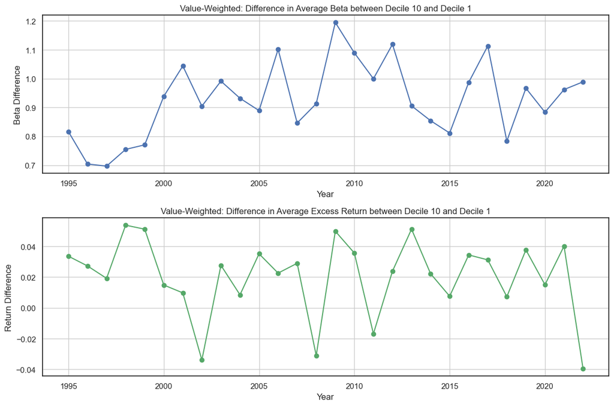

```python
# Check if result_vw contains the necessary columns for plotting
cols_to_check = [('beta_diff', ''), ('return_diff_vw', '')]

if all(col in result_vw.columns for col in cols_to_check):

    fig, axes = plt.subplots(nrows=2, ncols=1, figsize=(12, 8))

    # Plotting difference in beta
    result_vw[('beta_diff', '')].plot(ax=axes[0], marker='o')
    axes[0].set_title('Value-Weighted: Difference in Average Beta between Decile 10 and Decile 1')
    axes[0].set_ylabel('Beta Difference')
    axes[0].set_xlabel('Year')
    axes[0].grid(True)

    # Plotting difference in excess returns
    result_vw[('return_diff_vw', '')].plot(ax=axes[1], marker='o', color='g')
    axes[1].set_title('Value-Weighted: Difference in Average Excess Return between Decile 10 and Decile 1')
    axes[1].set_ylabel('Return Difference')
    axes[1].set_xlabel('Year')
    axes[1].grid(True)

    plt.tight_layout()
    plt.show()
```

## Findings

- Beta Difference:
  - For both value-weighted and equal-weighted portfolios, the beta difference between high beta (decile 10) and low beta (decile 1) stocks remains positive throughout the period from 1995 to 2022. This suggests that high beta stocks consistently have a higher systematic risk compared to low beta stocks.
- Return Difference:
  - The value-weighted portfolio shows a varied pattern over the years, with positive differences in most years but negative differences in some years like 2002, 2008, 2011, and 2022. This implies that high beta stocks do not consistently outperform low beta stocks when considering market capitalization.
  - The equal-weighted portfolio, on the other hand, consistently shows positive return differences between high beta and low beta stocks for most years, with a few exceptions like 2002, 2008, 2015, and 2022. This suggests that in an equal-weighted scenario, high beta stocks have generally provided better returns compared to low beta stocks.
- Statistical Significance:
  - The Newey-West t-statistic value is 4.957. Since this value is significantly greater than 2 (a common threshold for a 5% significance level), we can reject the null hypothesis that the average portfolio excess return or CAPM alpha is equal to zero. This indicates that the observed differences in portfolio returns are statistically significant and not due to random chance.
- Comparison of Portfolios:
  - Comparing the two portfolios, the equal-weighted portfolio seems to have a more consistent pattern of high beta stocks outperforming low beta stocks, as seen from the return differences.
  - The value-weighted portfolio, being influenced by market capitalization, sees the impact of larger firms' performance on the return differences, leading to more variability in the observed differences.

## CAPM and Market Beta

The Capital Asset Pricing Model (CAPM) predicts a positive relationship between market beta (systematic risk) and expected stock returns. However, the interpretation of the results provided earlier suggests some nuances and does not provide a straightforward confirmation or rejection of the CAPM.

Here's why:

1. Positive Beta-Return Relationship in Some Cases:
   - In both the value-weighted and equal-weighted portfolios, the beta difference (the difference in beta between high beta and low beta stocks) remains consistently positive over the years. This aligns with the CAPM prediction that higher beta stocks should provide higher expected returns.
2. Variable Return Patterns:
   - The CAPM assumes a linear relationship between beta and expected returns, but the return differences (excess returns) in the portfolios show variable patterns.
   - In the value-weighted portfolio, there are years (e.g., 2002, 2008, 2011, 2022) where high beta stocks do not outperform low beta stocks, indicating that the relationship is not always strictly positive.
   - In the equal-weighted portfolio, the return differences are generally positive, suggesting a more consistent relationship between beta and returns. However, there are still exceptions in some years.
3. Statistical Significance:
   - The Newey-West t-statistic suggests that the observed differences in portfolio returns are statistically significant. This means that beta does play a role in explaining stock returns, but the strength and consistency of that relationship vary over time.
4. Market Capitalization Effect:
   - The value-weighted portfolio considers market capitalization, which can influence the observed return differences. Larger firms have a greater impact on the portfolio's performance, and their performance may not always align with their beta values.

In summary, while there is evidence of a positive relationship between market beta and expected stock returns in the provided data, the relationship is not strictly linear or consistent over time. Various factors, including market capitalization and changing market conditions, can influence the observed patterns. Therefore, while the CAPM provides a theoretical framework for understanding this relationship, the real-world data suggests that other factors also play a significant role in determining stock returns.